# Red and white wines characterization

Arturo Prieto Tirado

6/12/2020

This project aims to study differences between red and white wines based on their characteristics. Some chemical related properties have been measured as well as their quality grading. There are a total of 12 numerical variables together with a categorical one (red or white wine). The total number of observations is 6497 distributed in 4898 white wines and 1599 red wines with no missing values. The variables that have been taken into account are the following:

- Fixed acidity: Measures the grams of tartaric acid per dm$^3$. These is one of the main acids in wine production, very important in determining the final colour and flavour.
- Volatile acidity: Measures the grams of acetic acid per dm$^3$, which is one of the main acids that is volatile (gas). Higher values will make the wine more acid to taste. Vinegar is made of this acid, so too much fermentation of bacteria that produce this acid lead to “vinegar-like” type of wine that everyone has experience with when smelling an old bottle that has been open and stored for too long.
- Citric acid: Measures the grams of citric acid per dm$^3$. There is little natural citric acid in grapes, if not negligible. When added, it is used for chemical stabilization of the wine, but usually in small quantities, otherwise the wine will have a citric taste, which is considered a defect.
- Residual sugar: Measures the grams of residual sugar per dm$^3$. This is the sugar left after the fermentation. So, a measure of the sweetness of the wine.
- Chlorides: Measures the grams of sodium chloride per dm$^3$. This is related to the saltiness of the wine
- Free sulfur dioxide: Measures the grams of free sulfur dioxide per dm$^3$. It is a measure of the amount of sulfur dioxide that is not bound to other molecules. Sulfur Dioxide is used to prevent oxidation and microbial growth.
- Total sulfur dioxide: Measures the grams of free sulfur dioxide per dm$^3$. It basically takes into account all the sulfur dioxide, the free ones plus the ones in the molecules of the wine.
- Density: Just the density in grams per dm$^3$.
- pH: Measures the pH in units of pH, that is, from 0 to 14. Wines are a little acid so they have moderately low pH values.
- Sulphates: Measures the grams of potassium sulfate per dm$^3$. This sulfate slows the aging of the wine and preserves its properties with time.
- Alcohol: Measures the percentage of alcohol in the wine.
- Quality: Measures the quality of the wine graded by experts from 0 to 10.

## Visual analysis

The first step is to take a look at the distribution of the variables. The categorical variable, quality, and the rest of them, shown in the following histograms. We will look as well at their quantiles, in case there is any limitation in the data.

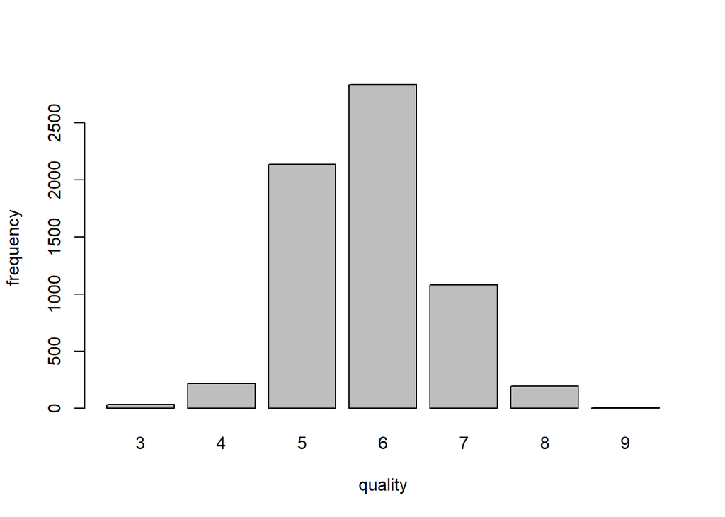

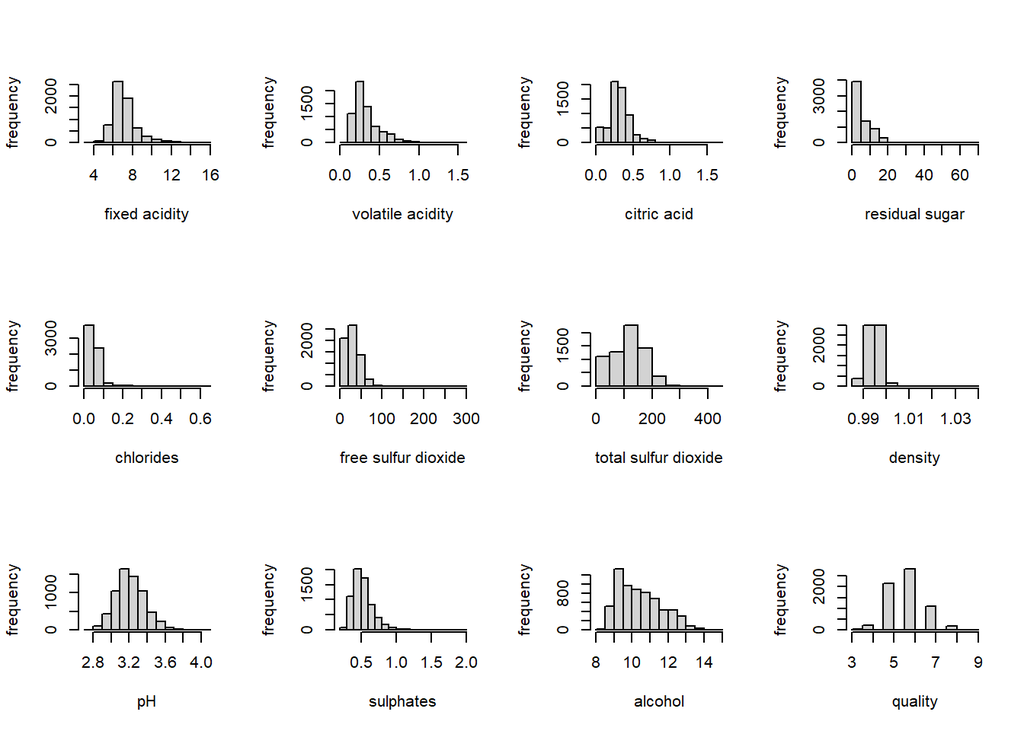

```
##  fixed acidity    volatile acidity  citric acid     residual sugar
##  Min.   : 3.800   Min.   :0.0800   Min.   :0.0000   Min.   : 0.600
##  1st Qu.: 6.400   1st Qu.:0.2300   1st Qu.:0.2500   1st Qu.: 1.800
##  Median : 7.000   Median :0.2900   Median :0.3100   Median : 3.000
##  Mean   : 7.215   Mean   :0.3397   Mean   :0.3186   Mean   : 5.443
##  3rd Qu.: 7.700   3rd Qu.:0.4000   3rd Qu.:0.3900   3rd Qu.: 8.100
##  Max.   :15.900   Max.   :1.5800   Max.   :1.6600   Max.   :65.800
##    chlorides       free sulfur dioxide total sulfur dioxide    density
##  Min.   :0.00900   Min.   :  1.00      Min.   :  6.0        Min.   :0.9871
##  1st Qu.:0.03800   1st Qu.: 17.00      1st Qu.: 77.0        1st Qu.:0.9923
##  Median :0.04700   Median : 29.00      Median :118.0        Median :0.9949
##  Mean   :0.05603   Mean   : 30.53      Mean   :115.7        Mean   :0.9947
##  3rd Qu.:0.06500   3rd Qu.: 41.00      3rd Qu.:156.0        3rd Qu.:0.9970
##  Max.   :0.61100   Max.   :289.00      Max.   :440.0        Max.   :1.0390
##        pH          sulphates         alcohol         quality
##  Min.   :2.720   Min.   :0.2200   Min.   : 8.00   Min.   :3.000
##  1st Qu.:3.110   1st Qu.:0.4300   1st Qu.: 9.50   1st Qu.:5.000
##  Median :3.210   Median :0.5100   Median :10.30   Median :6.000
##  Mean   :3.219   Mean   :0.5313   Mean   :10.49   Mean   :5.818
##  3rd Qu.:3.320   3rd Qu.:0.6000   3rd Qu.:11.30   3rd Qu.:6.000
##  Max.   :4.010   Max.   :2.0000   Max.   :14.90   Max.   :9.000
```

- For fixed acidity, we can see that the distribution is a bit skewed to the right and that most wines are located between around a mean value of 7.22 grams per dm3 with maximum and minimum values of 3.8 and 15.9 grams per dm3, respectively.
- For volatile acidity, we can see that the distribution, similarly to the fixed acidity, is a bit skewed to the right and that most wines are located at around a mean of 0.34 grams per dm3 with maximum and minimum values of 1.58 and 0.08 grams per dm3, respectively.
- For citrid acid, we can see that the distribution, similarly to the previous acidities, is a bit skewed to the right and that most wines are located at around a mean of 0.32 grams per dm3, with maximum and minimum of 1.66 and 0 grams per dm3, respectively.
- For Residual sugar, the distribution is clearly not symmetric, and we can see that most wines have low quantities of residual sugar, with the mean being 5.44 grams per dm3, while there is a minority with high values, the maximum of the distribution is 65.8 grams per dm3 while the minimum is 0.6 grams per dm3.
- For Chlorides, the distribution is clearly not symmetric, and we can see that most wines have low quantities of chlorides, with a mean value of 0.05 grams per dm3, while there is a minority with high values, the maximum of the distribution is 0.611 grams per dm3 while the minimum is 0.009 grams per dm3.
- For Free sulfur dioxide, the distribution is clearly not symmetric, and we can see that most wines have low quantities of chlorides, concentrated between a mean of 30.52 miligrams per dm3, while there is a minority with high values, the maximum of the distribution being 289 miligrams per dm3 while the minimum, 1 miligrams per dm3.
- For Total sulfur dioxide, the distribution is concentrated until 200, with mean 115.74 grams per dm3, from where there are just a few wines, being the maximum 440 and the minimum, 6 grams per dm3
- For Density, most wines have a density close to 1 (mean is 0.9946966 grams per dm3) which seems logical because that is the water density. Obviously, the wine can’t weight much less than the water because it’s mainly water and the additional components will probably increase the weight. This magnitude ranges from 0.98711 to 1.03898 grams per dm3
- For pH, the distribution of pH is more or less symmetric around a mean of 3.22, a bit skewed to the left, with minimum 2.72 and maximum 4.01.
- For Sulphates, the distribution is clearly right skewed around a mean of 0.53 grams per dm3 with minimum value 0.22 and maximum value 2 grams per dm3.
- For Alcohol, the distribution of alcohol % is right skewed around a mean value of 10.49 ranging from 8 to 14.9.
- Finally, for quality, the distribution ranges from 3 to 9, with a mean of 5.81. It is curious that there are no maximum grades out of 6000 wines.

We can see that most of them are very skewed, so we will take logarithms (which will be useful later). However, since the citric acid has values of zero, this supposes a problem because log(0) is not defined. The other variables don’t have this problem because they don’t get to 0. One could think on treating them like NAs but this could lead to any value, and we know the log we should get must be smaller than any of the others, just not minus infinity or a very big number (in absolute value), as well as the same value for all of them. These observations had all of them a value of 0, so we should replace all of them with the same value. So, I will add up a very small quantity to remediate this problem. However, this could introduce a bias and lead to very big (negative) values of the log of citric acid. Therefore, we should take this increment with care not to modify very much the original values but not creating absurdly large values as well. There are around 140 wines with citric acid 0 from which around 120 are red wines, so doing the wrong thing could create artificial outliers and bias towards red wines in the importance of citric acid as a key feature of red wines. Looking at the values of the citric acid, they are given with two significant decimals, this means that the measurement error of the values is of order $\pm$ 0.01 (otherwise the precision would be different). Therefore, a change of 0.005 should be inside the margin of error and seam reasonable, since log(0.02)=-3.9 , log(0.01)=-4.6 and log(0.005)=-5.3. Still, seeing if outliers have been created should be checked as well since it could happen that they were outliers from the beginning.

The distribution of the logarithms of the variables is shown in the following histograms. The log for quality was not taken since it was already symmetric and, having discrete values, it would have worsened the distribution.

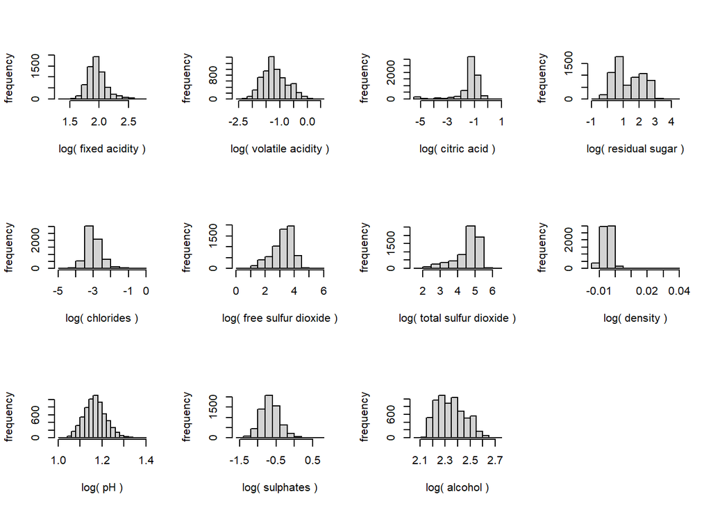

Finally, it would be interesting to see the distribution of the previous variables but regarding the different group they belong to, red or wine, as well as the scatterplot matrix to identify correlations between variables inside the whole dataset or inside a particular group. This is shown in the following kernel densities plots and in the scatterplot.

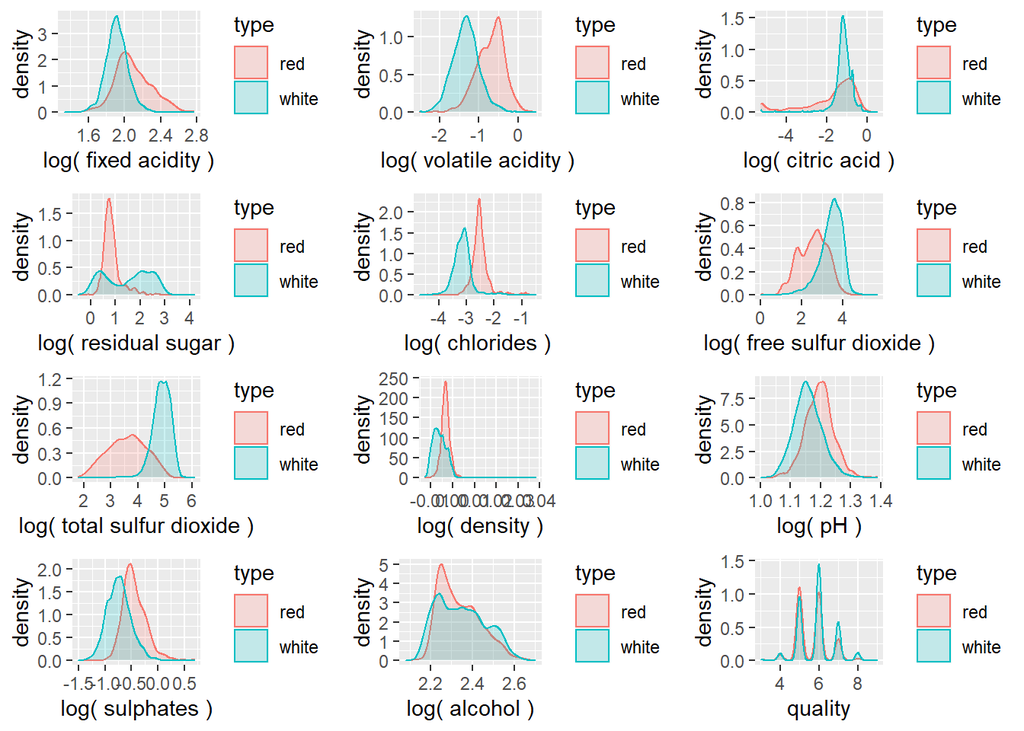

We can see that red wines have more acidity, but similar citric acid than white wines (except for a tail towards low values). In terms of sugar, red wines have low sugar while white ones are distributed with low and high values of sugar. Shapes for chlorides, pH and sulphates are very similar but shifted to higher values for red wines. In terms of sulfur dioxide (free and total), white wines have more than red wines. Alcohol is distributed more or less in a similar way between both groups and as well as density, but with higher mean density for red wines. Finally and surprisingly or not, there is no difference in quality between red and white wines. We can see that all the distributions overlap, so it won’t be immediate to determine the group just based on one variable even though there are some like chlorides that do have very little overlapping and could serve as distinctive traits between the groups.

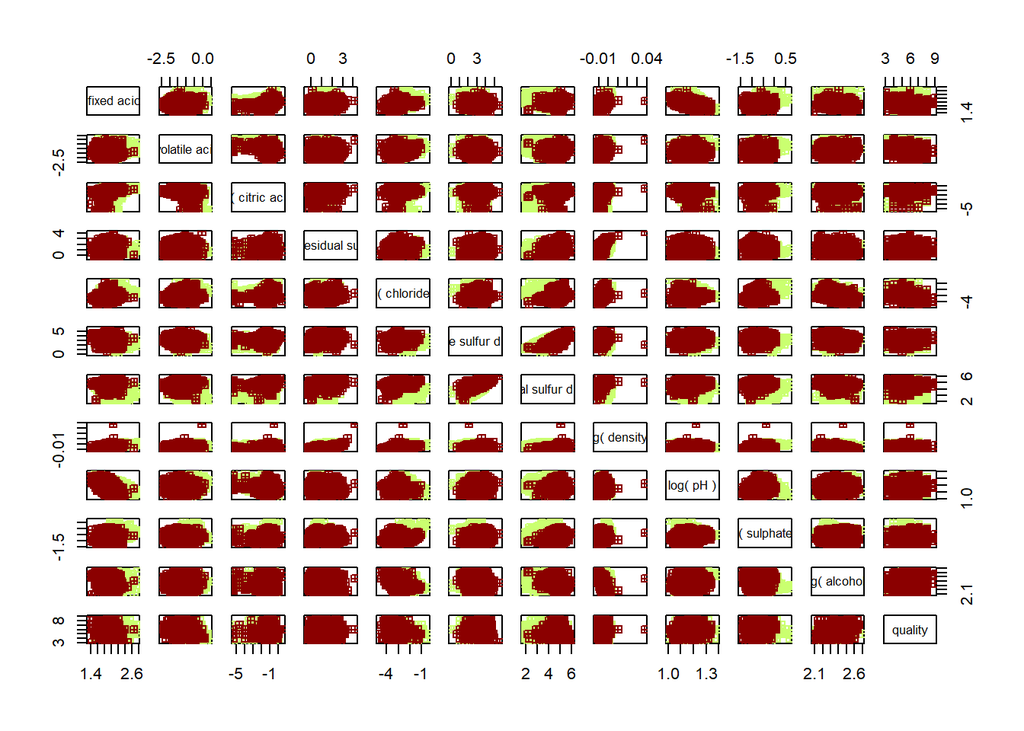

We don’t see any particular obvious relation between the variables, apart from the ones that share a chemical compound like the sulfur variables, that were expected to have some correlation, or pH and fixed acidity, that are related since pH is a measure of acidity. We can see some outliers, though, looking at high density values. One could try with Andrew’s plot or parallel coordinate plot. As can be seen in the following plots, it is clear that red and white wines follow different trends. It is also possible to see the presence of some outliers, since some of the lines (easier to see in the red wines) go outside the main curve. This is harder to see in the Andrew’s plot, where there is not a clear picture. We can see that this is a great motivation towards dimension reduction techniques like Principal Component Analysis, that we’ll work at later.

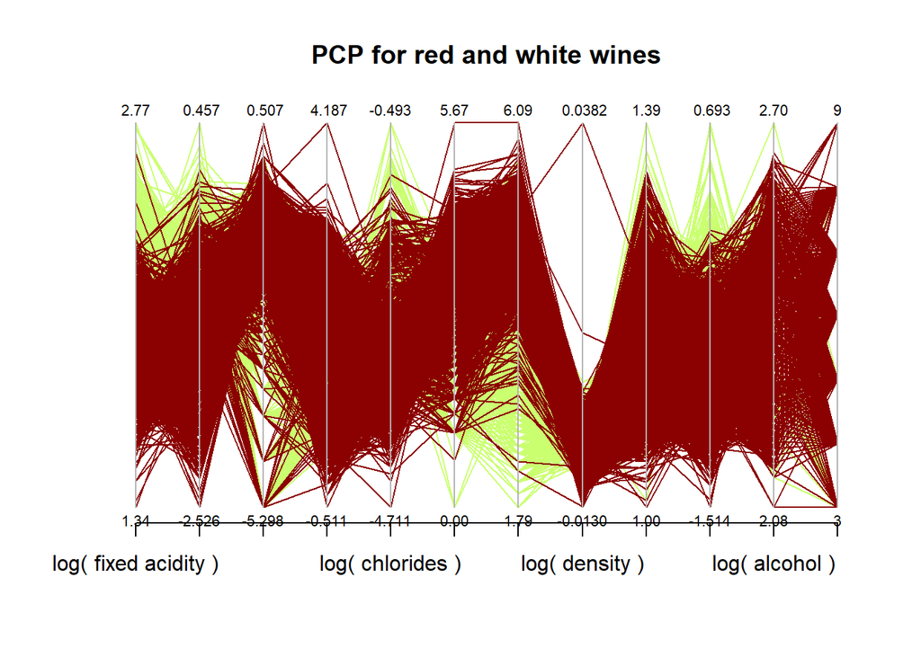

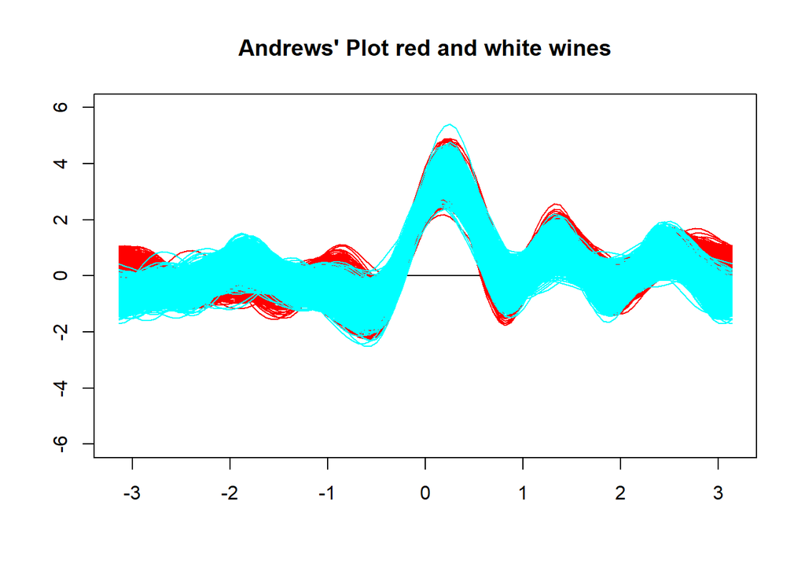

## Covariance, mean and correlations for the complete dataset

The next step is to estimate the covariance, mean and correlations for the complete dataset.

First, based on the results of the visual analysis, one should search for outliers, missing values or use sample shrinkage, etc. In our case, there are no missing values. Furthermore, there are only 12 variables and 6500 observations. The covariance matrix has order p(p-1)/2 so around 70 parameters. There are more than enough observations to estimate those parameters. In the same sense, both groups have enough observations individually 1600 and 4900 to calculate the individual covariance matrices. Therefore, there is no need to use the shrinkage covariance matrix as estimator of the true covariance matrix, since the sample one will not be singular.

So, we are left to check if there are outliers. Since computing the Mahalanobis distance requires estimates for mean and covariance, which are calculated using the outliers, one estimates these parameters with almost sure non-outliers (if this value is small, it might be useful to use the shrinkage covariance matrix here instead of the sample one: “minimum regularized covariance determinant estimators” MRCD) and with that Mahalanobis distance, judges which ones are outliers or not. Repeat this process a couple of times and find the estimation with the most non-outliers. These are the minimum covariance determinant estimators (MCD). In order to find the starting almost sure non-outliers one analyzes the variability they explain, i.e. the determinant, because the sum of the variances equals the sum of the eigenvalues and the determinant is the product of eigenvalues.

On the other hand, it is important to work with symmetric datasets. Since we have taken logs, this holds more or less, but we should still pay attention. Finally, not all of the variables have the same units of measurement so we will use normalized principal component analysis to avoid the effect of the units of measurement, otherwise, it will be impossible to compare numerical values like variances, for example.

Having said this, the mean vector for the complete dataset is the following:

```
##        log( fixed acidity )     log( volatile acidity )
##                 1.962001163                -1.180293762
##          log( citric acid )       log( residual sugar )
##                -1.343495036                 1.325704772
##            log( chlorides )  log( free sulfur dioxide )
##                -2.990624576                 3.216125948
## log( total sulfur dioxide )              log( density )
##                 4.563832672                -0.005322018
##                   log( pH )            log( sulphates )
##                 1.167679062                -0.666818353
##              log( alcohol )                     quality
##                 2.344317272                 5.818377713
```

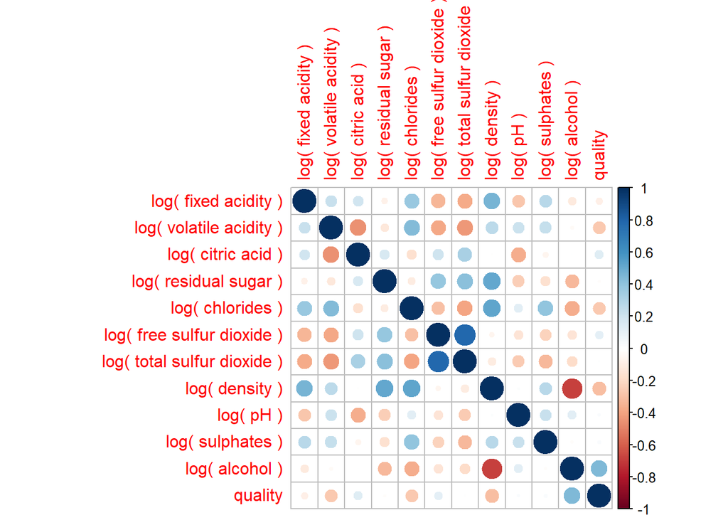

However, these values include possible outliers. The MCD estimates are the following:

```
##        log( fixed acidity )     log( volatile acidity )
##                    1.940948                   -1.277113
##          log( citric acid )       log( residual sugar )
##                   -1.160002                    1.426645
##            log( chlorides )  log( free sulfur dioxide )
##                   -3.086622                    3.390837
## log( total sulfur dioxide )              log( density )
##                    4.780413                   -0.005599
##                   log( pH )            log( sulphates )
##                    1.163563                   -0.700443
##              log( alcohol )                     quality
##                    2.341678                    5.871166
```

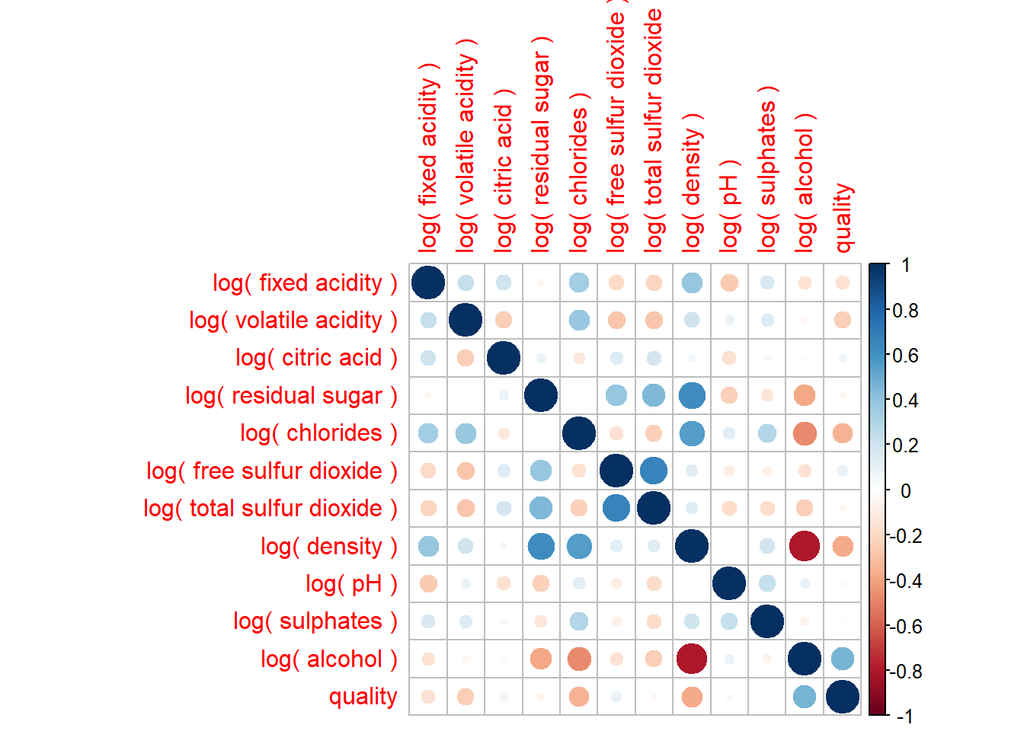

We can compare the correlation matrices for the robust estimators (MCD) and the sample ones and see the effect that outliers have in the correlation.

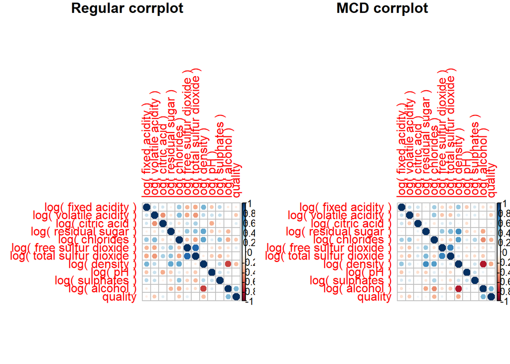

We can see that the outliers affect the correlation by diminishing existing correlations and creating or enhancing non-existent ones. For example, between acidities and sulfurs there seems to be some correlation that turned out to be caused by outliers. On the other hand, alcohol correlations to other variables like density or chlorides were hidden by outliers, although not in a great way.

Then, We can compare the eigenvalues of both covariance matrices and see how outliers affect them.

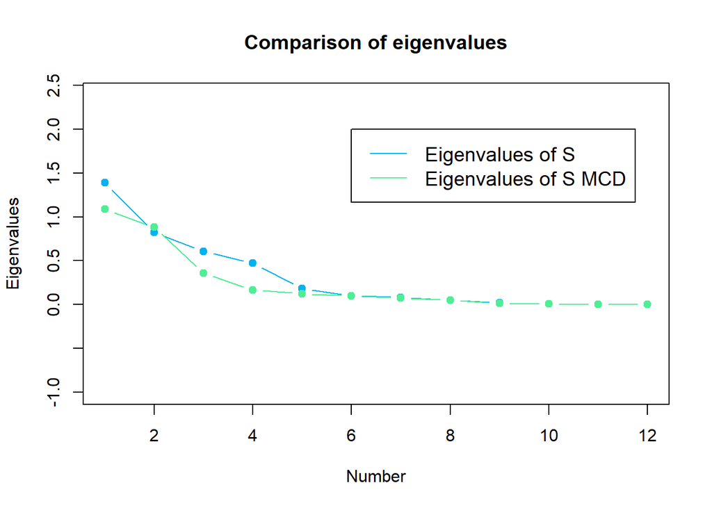

We can see that the eigenvalues of the robust covariance matrix are smaller. These eigenvalues are linked with the Principal Components of PCA, which extract the key features/groups in the dataset, mostly in the first PC. Clearly, outliers create variability and/or enhance groups artificially, so they affect greatly the first eigenvalues. If the first eigenvalue was linked to a type of group that was enhanced by the outliers, because they add variability, now its importance is reduced.

The next question that could be asked is how many outliers there are. This is shown in the following plot. From now on the outliers will be shown as orange points, while non-outliers, as green.

```
## [1] "the number of outliers in the complete dataset is:  991"
```

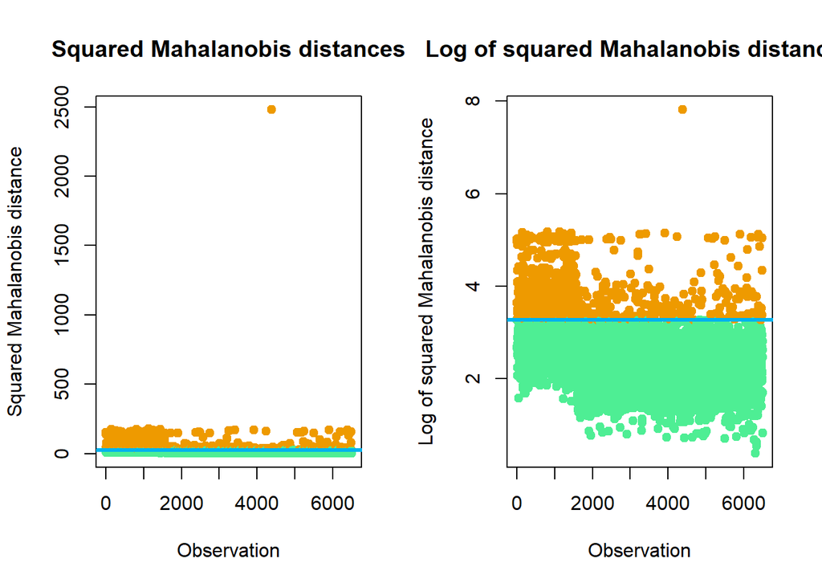

Looking at the log of square Mahalanobis distance (and the length of the vector), we see that there are 1000 outliers, which is around 15% of the dataset, but the important thing is that we get robust estimators of the mean, covariance and correlations.

We can see the different behaviour between outliers and non-outliers in the following plots:

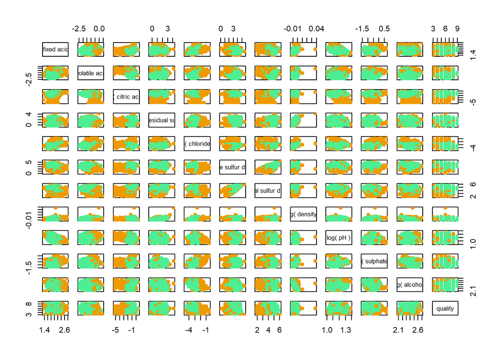

Most of the variables make no distinction between outliers, but citric acid clearly shows separation between them. In fact, it’s lower values of citric acid that are outliers. However, since the number of outliers (around 1000) is higher than the number of citric acid that gave problems (around 100), it seems unlikely that we had created artificial outliers, just that these were already outlier points.

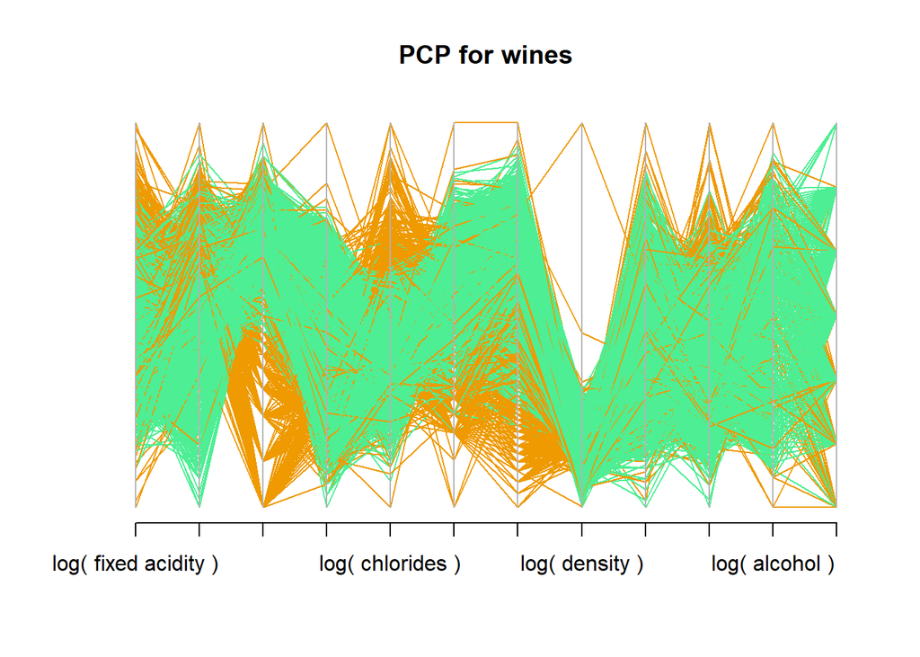

We can see in the PCP plot and in the Andrew’s plot that the outlier group clearly behaves differently than the non-outlier group.

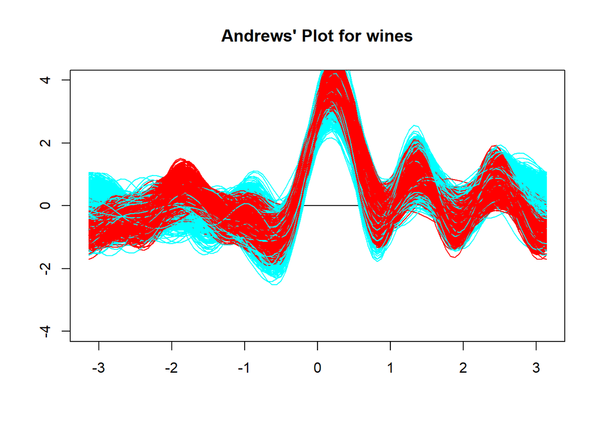

Now, we could repeat this analysis for each of the two groups, red wines and white wines. This way, we can compare the estimates of the mean, covariance and correlation to see if they change between the groups and also analyze the number of outliers, because it could happen that we had a great number of outliers because we had been mixing two different groups .

## Covariance, mean and correlation for red and white wines population

Let’s start repeating the analysis for the white wines group. Their mean vector is the following:

```
##        log( fixed acidity )     log( volatile acidity )
##                    1.917529                   -1.337575
##          log( citric acid )       log( residual sugar )
##                   -1.175423                    1.480928
##            log( chlorides )  log( free sulfur dioxide )
##                   -3.149011                    3.434852
## log( total sulfur dioxide )              log( density )
##                    4.878250                   -0.005995
##                   log( pH )            log( sulphates )
##                    1.158368                   -0.739148
##              log( alcohol )                     quality
##                    2.346046                    5.877909
```

And their correlation plot:

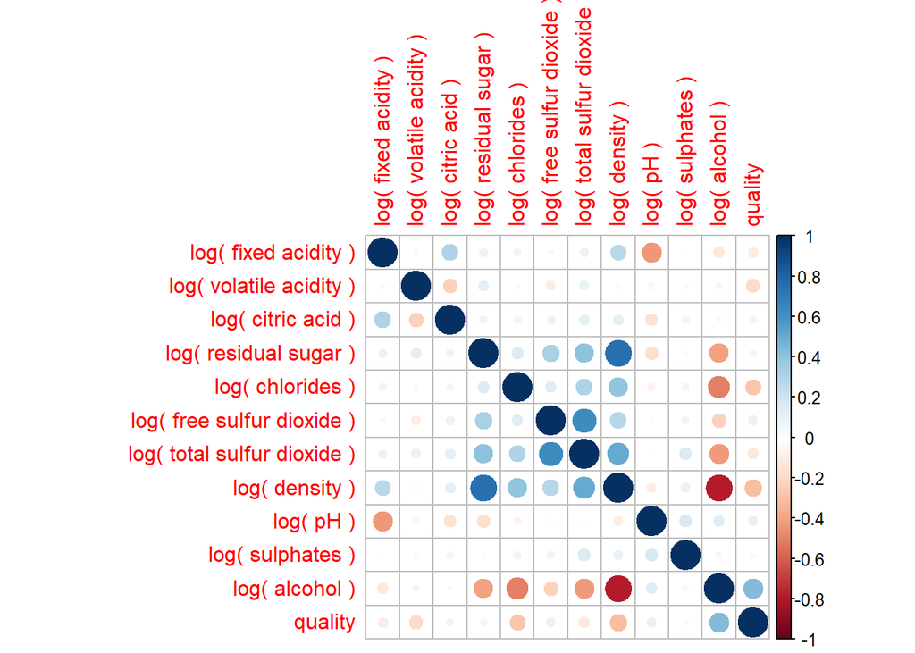

Now, we perform the MCD estimation, with the following robust mean vector resulting:

```
##        log( fixed acidity )     log( volatile acidity )
##                    1.918576                   -1.367271
##          log( citric acid )       log( residual sugar )
##                   -1.134017                    1.544454
##            log( chlorides )  log( free sulfur dioxide )
##                   -3.171146                    3.507693
## log( total sulfur dioxide )              log( density )
##                    4.907033                   -0.005915
##                   log( pH )            log( sulphates )
##                    1.159226                   -0.734096
##              log( alcohol )                     quality
##                    2.345708                    5.955796
```

In the same sense, the robust correlation is shown in the following plot:

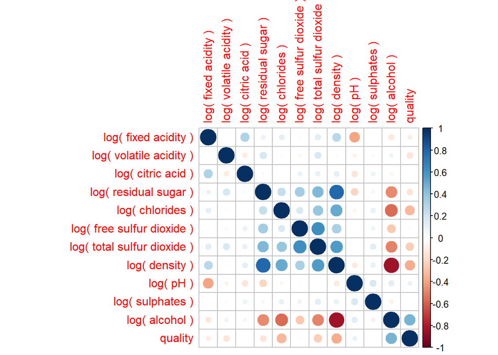

Finally, we can compare the correlation matrices for the robust estimators (MCD) and the normal ones and see the effect that outliers have in the correlation.

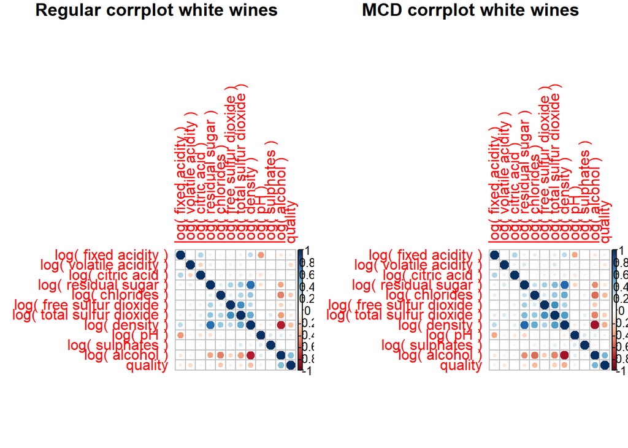

We can see that the outliers affect the correlation by diminishing existing correlations and creating or enhancing non-existent ones, but the general pattern stays the same.

Analogously as in the complete set case, we can compare the eigenvalues. However, in this case, the first eigenvalue is higher for the MCD case in contrast with the case with the complete dataset, where it was smaller. As we will see later, the first eigenvalue is related to the first principal component, which accounts for separation between red and white wines. Since now we are only dealing with white wines and since the eigenvalues describe characteristics of the variance that are “orthogonal”, it would be reasonable to think that the second general eigenvalue coincided more or less with the first eigenvalue in the white (and red) individual cases and therefore following more or less the same trend

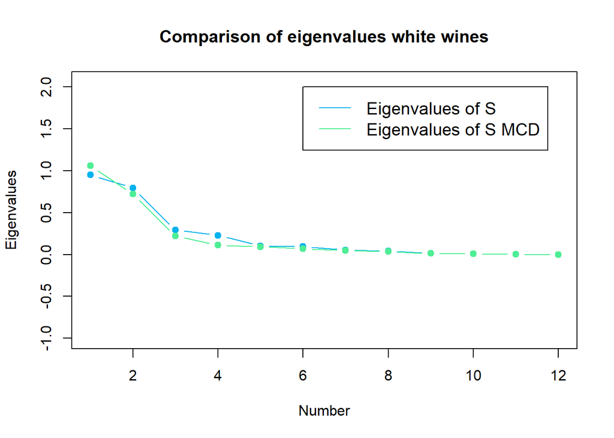

Finally, let’s see how many outliers are in the white wine group.

```
## [1] "the number of outliers in the white wines group is:  426"
```

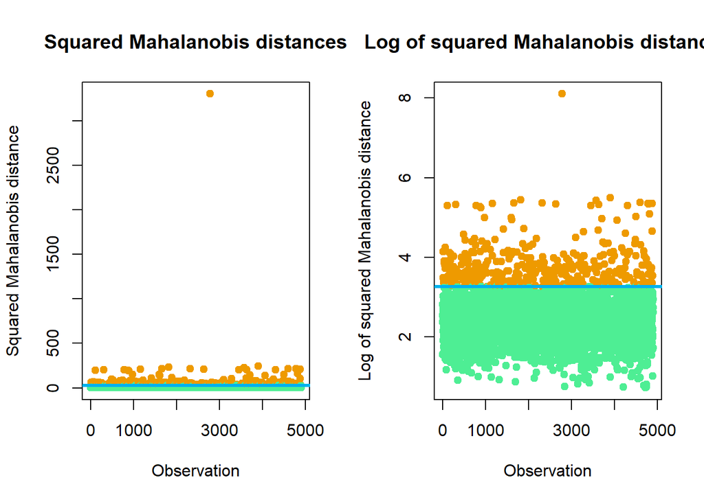

The distribution of the outliers is the following:

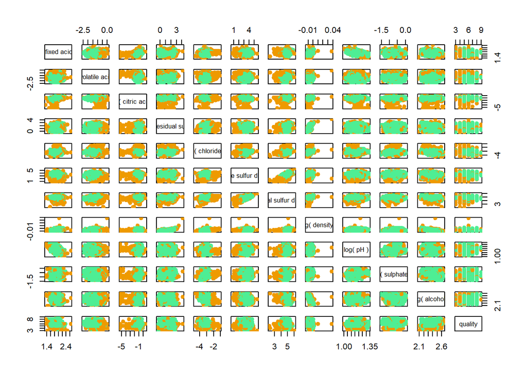

We can again see that citric acid is involved in outlier creation and finally, in the PCP plot, see as well that their behaviour is different.

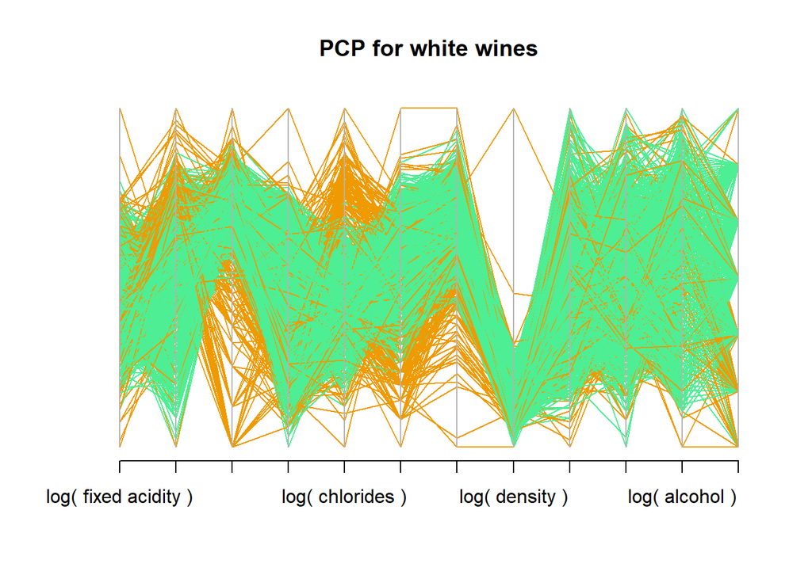

We can do the same for the red wines group. First estimate their sample mean vector and correlation:

```
##        log( fixed acidity )     log( volatile acidity )
##                     2.09823                    -0.69852
##          log( citric acid )       log( residual sugar )
##                    -1.85833                     0.85023
##            log( chlorides )  log( free sulfur dioxide )
##                    -2.50546                     2.54613
## log( total sulfur dioxide )              log( density )
##                     3.60072                    -0.00326
##                   log( pH )            log( sulphates )
##                     1.19620                    -0.44526
##              log( alcohol )                     quality
##                     2.33902                     5.63602
```

And correlation plot:

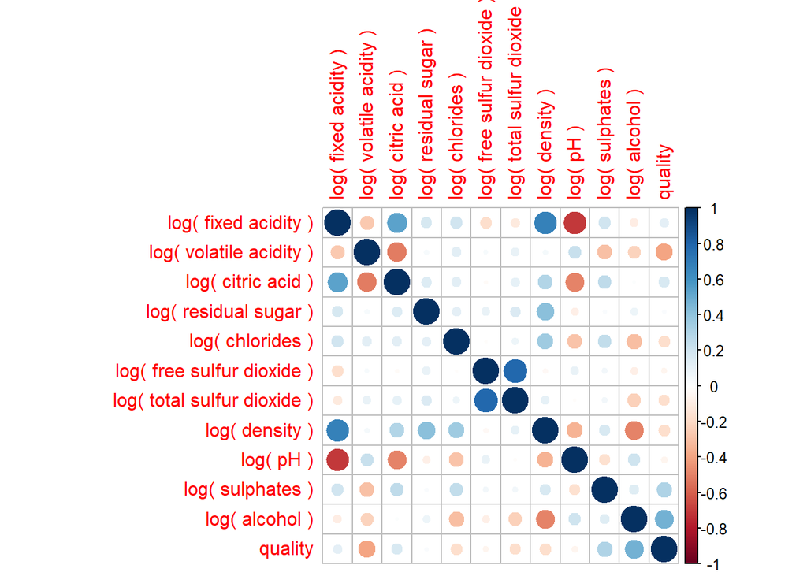

Now, we can compare with the MCD estimation:

```
##        log( fixed acidity )     log( volatile acidity )
##                    2.102836                   -0.701976
##          log( citric acid )       log( residual sugar )
##                   -1.892096                    0.780802
##            log( chlorides )  log( free sulfur dioxide )
##                   -2.546528                    2.556257
## log( total sulfur dioxide )              log( density )
##                    3.573684                   -0.003307
##                   log( pH )            log( sulphates )
##                    1.197462                   -0.469027
##              log( alcohol )                     quality
##                    2.333834                    5.640909
```

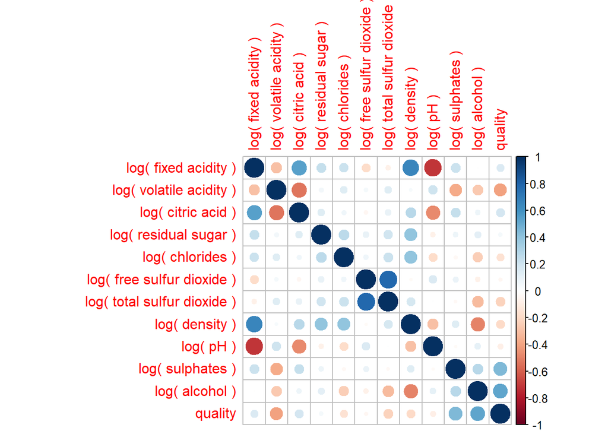

We can compare the correlation matrices for the robust estimators (MCD) and the sample ones and see the effect that outliers have in the correlation.

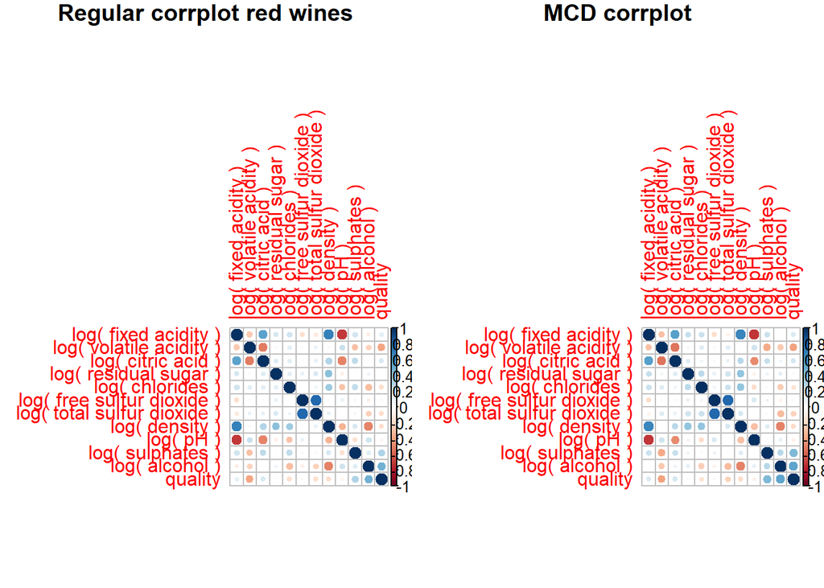

It is possible to see slight increases/decreases by removing the outliers, but, in general, there are no significant changes.

We can again compute the eigenvalues for sample and robust covariance and see the same effect we discussed in the white wine case in an identical way.

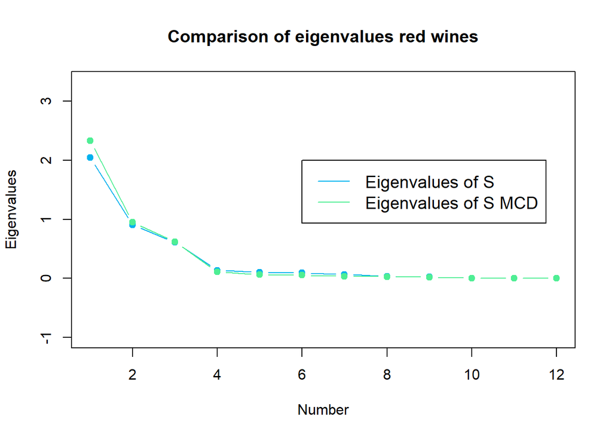

Finally, the following plot shows how many outliers there are in the red wine dataset

```
## [1] "the number of outliers in the red wines group is:  227"
```

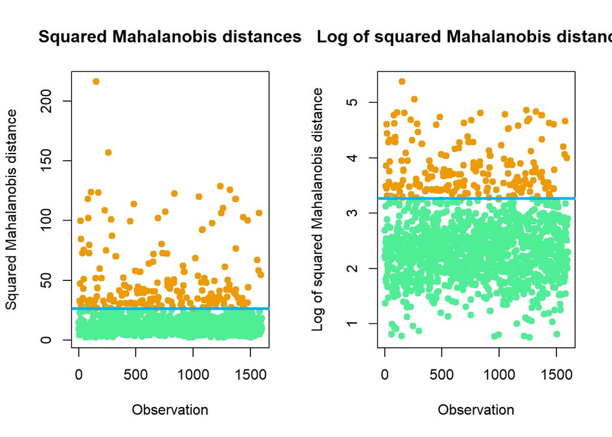

Looking at the log of square Mahalanobis distance (and the length of the vector), we see that there are 227 outliers. We can see that the total number of red+white outliers=426+227=653 is smaller than the number of outliers we got from the total dataset (1000), which means we might have overestimated the outliers due to the effect of the groups.

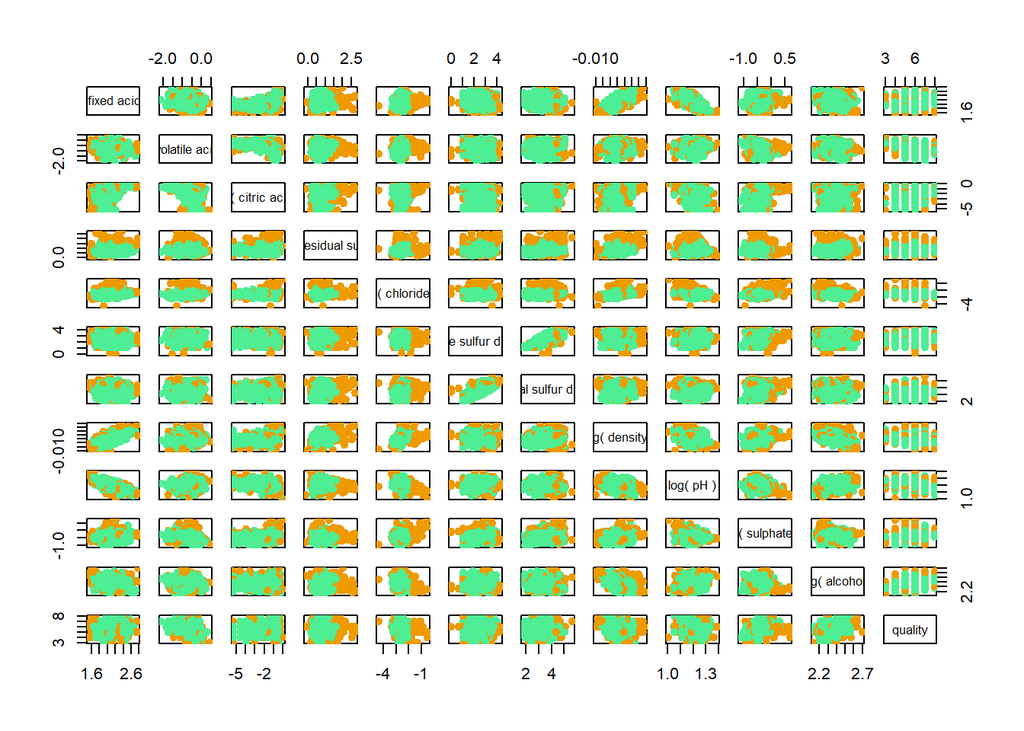

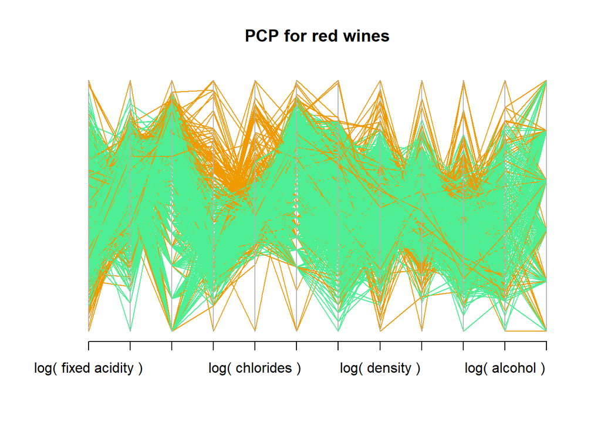

We can see in the PCP plot that the outlier group behaves differently than the non-outlier group.